# EuroLeague Final Four 2026 — Athens

## Part IV — The Semifinal Clashes

### SF1 — Olympiacos Piraeus vs. Fenerbahçe Beko Istanbul

*H2H sample: 2 games. Minimum 5 shared minutes required.*

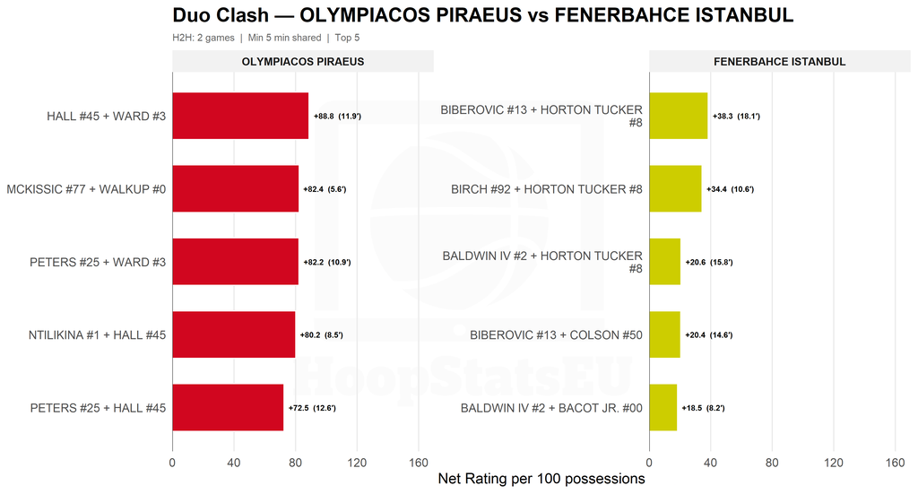

The head-to-head duo data tells one of the clearest stories in the entire analysis. Every single Olympiacos duo in the top five exceeds every single Fenerbahçe duo — not by a narrow margin, but by a canyon.

OLY’s top H2H duo, Hall + Ward, produced +88.8 net rating on nearly 12 minutes together in these two games. McKissic + Walkup (+82.4) and Peters + Ward (+82.2) follow. These are not cherry-picked from brief cameos: Peters + Hall accumulated 12.6 minutes at +72.5, and Ntilikina + Hall 8.5 minutes at +80.2. In head-to-head play against Fener, Olympiacos Community 2 combinations have been entirely dominant.

Fenerbahçe’s best H2H duo is Biberovic + Horton-Tucker at +38.3 on 18.1 minutes — a meaningful sample showing genuine effectiveness, but less than half of OLY’s best combination. Horton-Tucker’s presence in three of Fenerbahçe’s five best H2H duos makes him the most critical player for their side: if he is contained, their duo combinations collapse structurally.

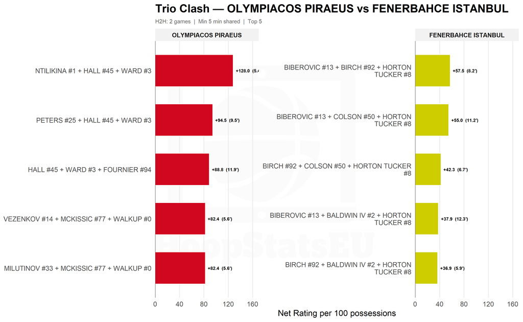

The trio clash is even more emphatic. Ntilikina + Hall + Ward produced +128 net rating on 5.4 minutes — the highest-rated combination in the entire H2H dataset for this tournament. Peters + Hall + Ward (+94.5 on 9.5 min) and Hall + Ward + Fournier (+88.8 on 11.9 min) confirm that the Hall–Ward axis is the spine of OLY’s H2H supremacy.

**Verdict for SF1:** The H2H data points strongly toward Olympiacos. Their Community 2 group has statistically dismantled Fenerbahçe’s best lineups in the two games they have shared. The critical coaching decision for Bartzokas is how quickly he accepts what the data shows and manages his rotation accordingly, prioritising Community 2 minutes even if that means reduced minutes for nominal starters. For Fenerbahçe’s bench, the challenge is structural: find a way to activate Community 3 against OLY, where they have not yet logged meaningful H2H time.

### SF2 — Valencia Basket vs. Real Madrid

*H2H sample: 2 games. Minimum 5 shared minutes required.*

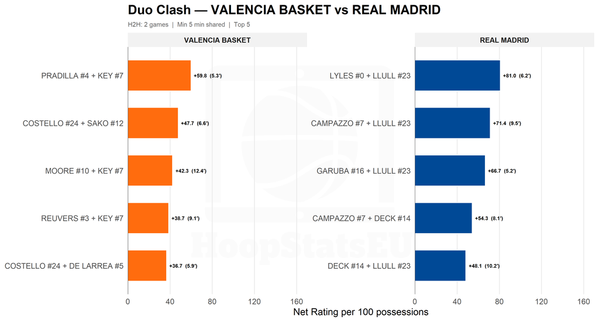

Madrid’s H2H duo superiority is prominent too. Lyles + Llull posted +81.0 net rating on 6.2 minutes. Campazzo + Llull added +71.4 on 9.5 minutes. Garuba + Llull was +66.7 on 5.2 minutes, and Campazzo + Deck posted +54.3 on 8.1 minutes. Deck + Llull (+48.1, 10.2 min) completes five Madrid duos between +48 and +81, all involving a Community 1 core name.

Llull is present in four of Madrid’s five best H2H duos. At 36 years old, Sergio Llull is performing as the decisive X-factor in this specific matchup. The question of his availability and minute load is the single most important variable in this semifinal.

Valencia’s best H2H duo — Pradilla + Key (+59.8, 5.3 min) — is genuinely impressive and actually exceeds some of Madrid’s mid-tier duos. Costello + Sako (+47.7, 6.6 min) and Moore + Key (+42.3, 12.4 min) provide real quality. But Valencia’s five-man top range spans +36.7 to +59.8, while Madrid’s spans +48.1 to +81.0. The gap at the top end is significant.

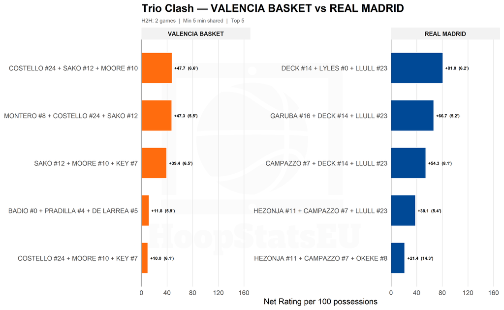

The trio clash reinforces the duo picture with one additional nuance. Madrid’s top three H2H trios — Deck + Lyles + Llull (+81.0), Garuba + Deck + Llull (+66.7), Campazzo + Deck + Llull (+54.3) — all feature Deck, a Community 2 member who appears nowhere in Madrid’s season-long top five trios. In H2H play specifically, Deck is the catalyst who makes the Llull-anchored triples devastating. This is a matchup-specific finding that the full-season data alone would have missed entirely. Another surprising finding is that Tavares is not part of any of the top five duos or trios against Valencia this season.

Valencia’s top two H2H trios — Costello + Sako + Moore (+47.7) and Montero + Costello + Sako (+47.3) — show genuine cohesion in their Community 2 group. These are not token appearances: both trios logged meaningful minutes and produced above-average net ratings. Costello and Sako are the duo-within-a-trio that Valencia should build around when they need a productive offensive possession.

The problem for Valencia is visible in their bottom two H2H trios: Badio + Pradilla + De Larrea (+11.8) and Costello + Moore + Key (+10.0). Their Community 1 trios and mixed-community combinations have been far less effective against Madrid, echoing the –30.7 community H2H rating for their younger group.

**Verdict for SF2:** The H2H data is clear: Real Madrid are the stronger team in this specific matchup, and the gap is widest at the lineup-combination level. Their Llull-anchored duos and Deck-infused trios have dominated Valencia in both regular season encounters. Valencia’s only realistic path is to live entirely in their Community 2 combinations — Costello, Sako, Moore, Key, Montero — from the opening tip, and hope that the Madrid defense deployed in Athens is less devastating than the one seen in H2H. If Valencia’s Community 1 group (the –30.7 net community) spends significant time together, the result will almost certainly mirror their previous encounters.

## Closing Thoughts

The EuroLeague Final Four has become the sport’s most compressed and demanding tournament format — two games in three days, no margin for adjustment, no second chance. In that context, H2H data is not a curiosity; it is the most relevant sample available.

But basketball is played on the floor, not in spreadsheets. Fenerbahçe’s Community 3 (Melli, Jantunen, Hall, Boston Jr. — their best season-long group at +21.4) has not yet been exposed to meaningful H2H minutes against Olympiacos, which means it remains an untested weapon. And Valencia’s Costello–Sako–Moore core produced H2H trio ratings above +47, which means they have at least one real combination capable of stringing together productive possessions against Madrid’s defense.

What the networks tell us, ultimately, is this: the team that wins will be the one whose internal communities remain connected under pressure. Fragmented networks tend to collapse in single-elimination formats. Olympiacos and Real Madrid have the more coherent internal architectures heading into Athens. The data says *trust the network*.

**Methodology note:** All ratings are per 100 possessions, recency-weighted. Assist network analysis covers the last 15 games per team. Duo/trio analysis covers the last 10 regular season games per team plus applicable playoff series, with Olympiacos playoff games against Monaco excluded from recent-form ratings due to opponent circumstances. Minimum thresholds: full-season duos ≥ 100 weighted possessions, trios ≥ 60. Recent-form duos ≥ 60, trios ≥ 35. H2H combinations ≥ 5 shared minutes.